# 03_PreProcessing_Lecture.Rmd

Morrow Zhang

2026-04-21

# Goals

Goal of this analysis is to remove any ASVS from chloroplasts and mitochondria. Evaluate negative and positive controls while removing the negative control. Check for reverse complements and sequencing depth of samples. Add the metada for my dataset and write a preprocessed_physeq for downstream workflow.

# Set up the Environment

```r
# Set seed
set.seed(238428)

# Time of start
start_time <- Sys.time()

# Load packages
pacman::p_load(devtools, phyloseq, Biostrings, tidyverse, dada2, patchwork,
               # Note to add ggpubr & rstatix!!
               ggpubr, rstatix, install = FALSE)
knitr::opts_chunk$set(
  echo = TRUE,
  fig.align = "center",
  fig.path = "figures/03_PreProcessing/"
)
```

# Load Phyloseq Data

```r
load("data/raw_physeq.RData")

raw_physeq
```

```
## phyloseq-class experiment-level object
## otu_table()   OTU Table:         [ 2886 taxa and 49 samples ]
## sample_data() Sample Data:       [ 49 samples by 37 sample variables ]
## tax_table()   Taxonomy Table:    [ 2886 taxa by 9 taxonomic ranks ]
```

# Clean up the Data

## Remove Chloroplasts and Mitochondria

```r
noChloros_physeq <-
  raw_physeq %>%
  subset_taxa(Order != "Chloroplast" | is.na(Order))

num_chloro_ASVs <- ntaxa(raw_physeq) - ntaxa(noChloros_physeq)
num_chloro_ASVs
```

```
## [1] 0
```

```r
noChlorosMitos_physeq <-
  noChloros_physeq %>%
  subset_taxa(Family != "Mitochondria" | is.na(Family))

num_mito_ASVs <- ntaxa(noChloros_physeq) - ntaxa(noChlorosMitos_physeq)
num_mito_ASVs
```

```
## [1] 0
```

### INTERPRETATION #1

There were 0 chloroplast ASVs and 0 mitochondrial ASVs detected in my dataset. This seems reasonable because my samples are rectal swab microbiome samples from human patients, which are expected to primarily contain bacterial DNA rather than plant-derived chloroplast sequences. Additionally, the study included contamination monitoring and filtering steps, which likely removed potential mitochondrial or chloroplast sequences if present.

# Evaluate and remove negative controls

```r
# Check if there is negative control

sample_names(noChlorosMitos_physeq)
```

```
##  [1] "SRR35320041" "SRR35320051" "SRR35320062" "SRR35320071" "SRR35320072"
##  [6] "SRR35320073" "SRR35320074" "SRR35320075" "SRR35320076" "SRR35320077"
## [11] "SRR35320078" "SRR35320079" "SRR35320080" "SRR35320081" "SRR35320082"
## [16] "SRR35320084" "SRR35320085" "SRR35320086" "SRR35320087" "SRR35320088"
## [21] "SRR35320089" "SRR35320090" "SRR35320091" "SRR35320092" "SRR35320093"
## [26] "SRR35320094" "SRR35320095" "SRR35320100" "SRR35320110" "SRR35320111"
## [31] "SRR35320112" "SRR35320113" "SRR35320114" "SRR35320115" "SRR35320116"
## [36] "SRR35320117" "SRR35320118" "SRR35320119" "SRR35320120" "SRR35320121"
## [41] "SRR35320122" "SRR35320123" "SRR35320124" "SRR35320125" "SRR35320126"
## [46] "SRR35320128" "SRR35320139" "SRR35320140" "SRR35320141"
```

### INTERPRETATION #2

No negative control samples were detected in my dataset. All sample names appear as SRR accession IDs, and none are labeled as controls.

# Positive Controls

```r
# check if there is positive control
sample_data(noChlorosMitos_physeq)
```

```
##                     Run Assay.Type AvgSpotLen    Bases   BioProject
## SRR35320041 SRR35320041   AMPLICON        600 42870559 PRJNA1321953
## SRR35320051 SRR35320051   AMPLICON        601 52869386 PRJNA1321953
## SRR35320062 SRR35320062   AMPLICON        601 48220175 PRJNA1321953
## SRR35320071 SRR35320071   AMPLICON        600 41476966 PRJNA1321953
## SRR35320072 SRR35320072   AMPLICON        600 27932952 PRJNA1321953
## SRR35320073 SRR35320073   AMPLICON        600 27458118 PRJNA1321953
## SRR35320074 SRR35320074   AMPLICON        600 30216971 PRJNA1321953
## SRR35320075 SRR35320075   AMPLICON        601 21387436 PRJNA1321953
## SRR35320076 SRR35320076   AMPLICON        600 26428722 PRJNA1321953
## SRR35320077 SRR35320077   AMPLICON        600 27191972 PRJNA1321953
## SRR35320078 SRR35320078   AMPLICON        600 21232475 PRJNA1321953
## SRR35320079 SRR35320079   AMPLICON        600 27582655 PRJNA1321953
## SRR35320080 SRR35320080   AMPLICON        600 31526496 PRJNA1321953
## SRR35320081 SRR35320081   AMPLICON        600 20725706 PRJNA1321953
## SRR35320082 SRR35320082   AMPLICON        600 23856070 PRJNA1321953
## SRR35320084 SRR35320084   AMPLICON        600 31436524 PRJNA1321953
## SRR35320085 SRR35320085   AMPLICON        600 30019709 PRJNA1321953
## SRR35320086 SRR35320086   AMPLICON        601 22421035 PRJNA1321953
## SRR35320087 SRR35320087   AMPLICON        600 29898013 PRJNA1321953
## SRR35320088 SRR35320088   AMPLICON        598 24587995 PRJNA1321953
## SRR35320089 SRR35320089   AMPLICON        600 28691764 PRJNA1321953
## SRR35320090 SRR35320090   AMPLICON        601 27029497 PRJNA1321953
## SRR35320091 SRR35320091   AMPLICON        600 31827759 PRJNA1321953
## SRR35320092 SRR35320092   AMPLICON        601 43719025 PRJNA1321953
## SRR35320093 SRR35320093   AMPLICON        600 23536717 PRJNA1321953
## SRR35320094 SRR35320094   AMPLICON        601 27966184 PRJNA1321953
## SRR35320095 SRR35320095   AMPLICON        600 37675072 PRJNA1321953
## SRR35320100 SRR35320100   AMPLICON        600 53610235 PRJNA1321953
## SRR35320110 SRR35320110   AMPLICON        600 25163718 PRJNA1321953
## SRR35320111 SRR35320111   AMPLICON        600 36565624 PRJNA1321953
## SRR35320112 SRR35320112   AMPLICON        600 37500250 PRJNA1321953
## SRR35320113 SRR35320113   AMPLICON        600 33211193 PRJNA1321953
## SRR35320114 SRR35320114   AMPLICON        600 47077172 PRJNA1321953
## SRR35320115 SRR35320115   AMPLICON        601 34126997 PRJNA1321953
## SRR35320116 SRR35320116   AMPLICON        600 34440359 PRJNA1321953
## SRR35320117 SRR35320117   AMPLICON        600 33302037 PRJNA1321953
## SRR35320118 SRR35320118   AMPLICON        601 20473521 PRJNA1321953
## SRR35320119 SRR35320119   AMPLICON        600 35778012 PRJNA1321953
## SRR35320120 SRR35320120   AMPLICON        600 36178456 PRJNA1321953
```

[output cut: 545 more lines]

```
## SRR35320116 SRP618695
## SRR35320117 SRP618695
## SRR35320118 SRP618695
## SRR35320119 SRP618695
## SRR35320120 SRP618695
## SRR35320121 SRP618695
## SRR35320122 SRP618695
## SRR35320123 SRP618695
## SRR35320124 SRP618695
## SRR35320125 SRP618695
## SRR35320126 SRP618695
## SRR35320128 SRP618695
## SRR35320139 SRP618695
## SRR35320140 SRP618695
## SRR35320141 SRP618695
```

### INTERPRETATION #3

My dataset does not appear to include a mock community sample. The sample names in the downloaded dataset are all SRR accession IDs for human gut samples, and there is no sample labeled as a mock control.

# Reverse Complements

```r
# Pull out the Taxa table

tax_table <-
  noChlorosMitos_physeq %>%
  tax_table() %>%
  data.frame()

# Grab ASV sequences and names

asv_names <- tax_table$ASV
asv_seqs <- tax_table$ASVseqs

# Create empty comparison matrix

asv_rev_comp <- matrix(nrow=length(asv_seqs), ncol = length(asv_seqs))

# Fix names in rows and columns

rownames(asv_rev_comp) <- asv_names
colnames(asv_rev_comp) <- asv_names

# Convert sequences to Biostrings
asv_dna <- DNAStringSet(asv_seqs)

# Take a look
head(asv_dna)
```

```
## DNAStringSet object of length 6:
##     width seq
## [1]   401 TGGGGAATATTGCACAATGGGGGAAACCCTGATG...GACGCTGAGGTACGAAAGCGTGGGGAGCAAACA
## [2]   401 TGGGGAATATTGCACAATGGAGGGAACTCTGATG...GACGCTGAGGAACGAAAGCGTGGGTAGCAAACA
## [3]   422 TGAGGAATATTGGTCAATGGGCGCTAGCCTGAAC...GACGCTTAAGCTCGAAGGTGCGGGTATCAAACA
## [4]   400 TGGGGAATTTTGCACAATGGGGGAAACCCTGATG...GACGCTGAGGTACGAAAGCGTGGGTAGCAAACA
## [5]   402 TGGGGAATATTGCACAATGGGGGAAACCCTGATG...GACGCTGAGGCACGAAAGCGTGGGGAGCAAACA
## [6]   402 TGGGGAATATTGCACAATGGAGGGAACTCTGATG...GACGCTCAGGCACGAAAGCGTGGGGAGCAAACA
```

```r
asv_rev_dna <- reverseComplement(asv_dna)


for(i in 1:length(asv_seqs)){
  match_vec <- asv_dna[i] == asv_rev_dna
  asv_rev_comp[,i] <- match_vec
}

cat("For", sum(asv_rev_comp) / 2,"ASVs, the reverse complement will need to be removed")
```

```
## For 0 ASVs, the reverse complement will need to be removed
```

### INTERPRETATION #4

There were 0 reverse complement ASVs detected in my dataset. This indicates that no ASV sequences were identified as reverse complements of each other, so no sequences need to be removed at this step.

# Sequencing Depth

```r
# Make a metadata dataframe for joining

metadata_df <-
  noChlorosMitos_physeq %>%
  sample_data() %>%
  data.frame() %>%
  tibble::rownames_to_column(var = "names") %>%
  dplyr::mutate(
    AttemptStatus = ifelse(
      grepl("non attempters", source_material_id),
      "Non-attempter",
      "Attempter"
    )
  )

# What is the library size/sequencing depth for each sample

seqSums_df <-
  noChlorosMitos_physeq %>%
  otu_table() %>%
  colSums() %>%
  data.frame() %>%
  rownames_to_column(var = "names") %>%
  left_join(., metadata_df, by = "names")

# Rename second columns

colnames(seqSums_df)[2] <- "TotalSeqs"

# Take a look

dim(seqSums_df)
```

```
## [1] 49 40
```

```r
head(seqSums_df)
```

```
##         names TotalSeqs         Run Assay.Type AvgSpotLen    Bases   BioProject
## 1 SRR35320041     38755 SRR35320041   AMPLICON        600 42870559 PRJNA1321953
## 2 SRR35320051     45635 SRR35320051   AMPLICON        601 52869386 PRJNA1321953
## 3 SRR35320062     45397 SRR35320062   AMPLICON        601 48220175 PRJNA1321953
## 4 SRR35320071     37841 SRR35320071   AMPLICON        600 41476966 PRJNA1321953
## 5 SRR35320072     27531 SRR35320072   AMPLICON        600 27932952 PRJNA1321953
## 6 SRR35320073     26875 SRR35320073   AMPLICON        600 27458118 PRJNA1321953
##      BioSample                      BioSampleModel    Bytes   Center.Name
## 1 SAMN51231085 MIMS.me,MIGS/MIMS/MIMARKS.human-gut 27501260 JOHNS HOPKINS
## 2 SAMN51231084 MIMS.me,MIGS/MIMS/MIMARKS.human-gut 33837100 JOHNS HOPKINS
## 3 SAMN51231083 MIMS.me,MIGS/MIMS/MIMARKS.human-gut 30319981 JOHNS HOPKINS
## 4 SAMN51231082 MIMS.me,MIGS/MIMS/MIMARKS.human-gut 26186708 JOHNS HOPKINS
## 5 SAMN51231126 MIMS.me,MIGS/MIMS/MIMARKS.human-gut 17133688 JOHNS HOPKINS
## 6 SAMN51231125 MIMS.me,MIGS/MIMS/MIMARKS.human-gut 16680476 JOHNS HOPKINS
##   Collection_Date collection_method Consent DATASTORE.filetype
```

[output cut: 55 more lines]

```r
seqSums_df %>%
  dplyr::select(names, TotalSeqs) %>%
  arrange(TotalSeqs) %>%
  head()
```

```
##         names TotalSeqs
## 1 SRR35320081     12368
## 2 SRR35320118     15107
## 3 SRR35320075     17176
## 4 SRR35320078     17534
## 5 SRR35320124     20917
## 6 SRR35320122     21234
```

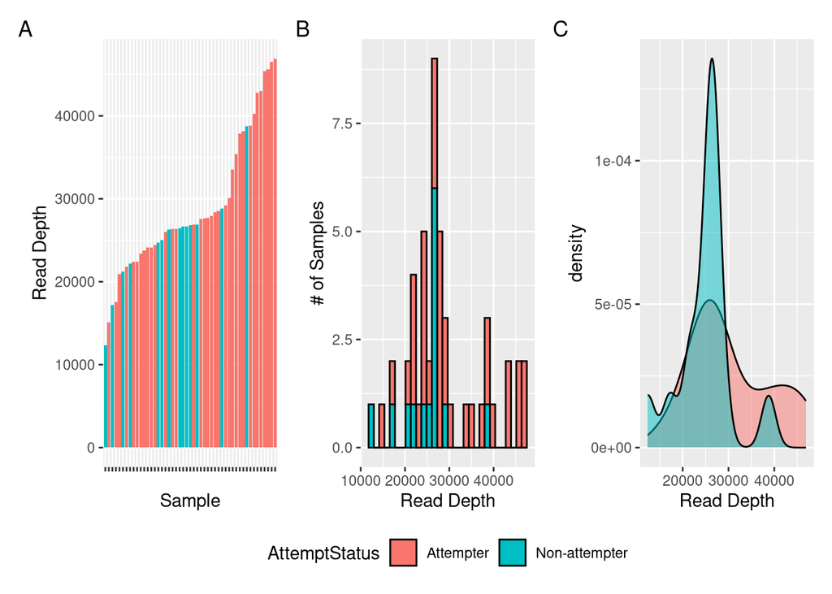

```r
# bar plot
numSeq_bar_plot <-
  seqSums_df %>%
  ggplot(aes(x = reorder(names, TotalSeqs), y = TotalSeqs,
             fill = AttemptStatus)) +
  geom_bar(stat = "identity") +
  theme(axis.text.x = element_blank()) +
  labs(y = "Read Depth", x = "Sample") +
  theme(legend.position = "none")

# histogram
numSeq_hist_plot <-
  seqSums_df %>%
  ggplot(aes(x = TotalSeqs, fill = AttemptStatus)) +
  geom_histogram(color = "black") +
  labs(y = "# of Samples", x = "Read Depth") +
  theme(legend.position = "bottom")

# Density plot
numSeq_density_plot <-
  seqSums_df %>%
  ggplot(aes(TotalSeqs, fill = AttemptStatus)) +
  geom_density(alpha = 0.5) +
  labs(x = "Read Depth") +
  theme(legend.position = "none")

numSeq_bar_plot + numSeq_hist_plot + numSeq_density_plot +
  plot_annotation(tag_levels = "A")
```

### INTERPRETATION #5

Overall, the sequencing depth across samples appears sufficient and relatively consistent, available for reliable downstream diversity analysis.

# Remove samples with few reads

```r
# no longer needing to remove
summary(seqSums_df$TotalSeqs)
```

```
##    Min. 1st Qu.  Median    Mean 3rd Qu.    Max.
##   12368   24112   26815   28916   33564   46910
```

```r
#sum(seqSums_df$TotalSeqs < 100)

#seqSums_df %>%
  #dplyr::filter(TotalSeqs < 100) %>%
  #dplyr::select(names, TotalSeqs) %>%
  #dplyr::arrange(TotalSeqs)

#preprocessed_physeq <-
 # prune_samples(
   # !(sample_names(noChlorosMitos_physeq) %in% c(
   #   "SRR35320078",
   #   "SRR35320071",
   #   "SRR35320081",
   #  "SRR35320073",
    #  "SRR35320124"
   # )),
   # noChlorosMitos_physeq
 # )

preprocessed_physeq <- noChlorosMitos_physeq
min(sample_sums(preprocessed_physeq))
```

```
## [1] 12368
```

```r
nsamples(preprocessed_physeq)
```

```
## [1] 49
```

```r
# Check for sequencing depth

seqSums_df %>%
  dplyr::select(names, TotalSeqs) %>%
  arrange(TotalSeqs)
```

```
##          names TotalSeqs
## 1  SRR35320081     12368
## 2  SRR35320118     15107
## 3  SRR35320075     17176
## 4  SRR35320078     17534
## 5  SRR35320124     20917
## 6  SRR35320122     21234
## 7  SRR35320123     21842
## 8  SRR35320086     22153
## 9  SRR35320121     22401
## 10 SRR35320094     22419
## 11 SRR35320088     23355
## 12 SRR35320110     23764
## 13 SRR35320093     24112
## 14 SRR35320080     24160
```

[output cut: 35 more lines]

# Write out the data

```r
save(
  preprocessed_physeq,
  file = "data/preprocessed_phyloseq.RData"
)
```

# Final info for reproducibility

```r
# Check Render Time

end_time <- Sys.time()
end_time
```

```
## [1] "2026-04-21 14:30:27 EDT"
```

```r
elapsed_time <- round((end_time - start_time), 3)
elapsed_time
```

```
## Time difference of 15.149 secs
```